# exploratory_network_analysis

### Transformations

Shepard diagrams allow us to visualize how well our MDS configuration fits our dissimilarity matrix. When the dissimilarities align in a linear fashion, a ratio or interval MDS is most appropriate. In other cases, a nonlinear transformation such as ordinal MDS or spline MDS may be more appropriate. The normalized stress values (plotted in each graph) can help guide us in deciding which transformation provides the best fit.

#### Shepard diagrams for all scales

It’s possible to see that Spline and Ordinal MDS are the transformations with less stress, with the later showing a slightly better result.

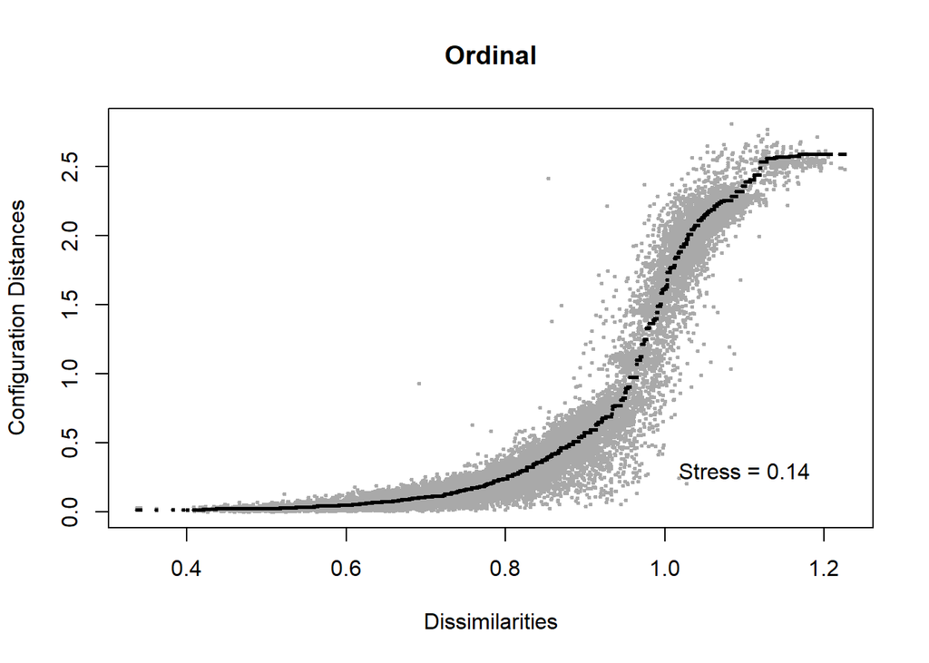

```r
gen_zeroorder <- cor(df[9:214])

dissimilarities <- sim2diss(gen_zeroorder)

MDS_ordinal <- mds(dissimilarities, type = 'ordinal')
plot(MDS_ordinal, plot.type = "Shepard", main = "Ordinal")
text(1.1,0.3, paste("Stress =", round(MDS_ordinal$stress,2)))
```

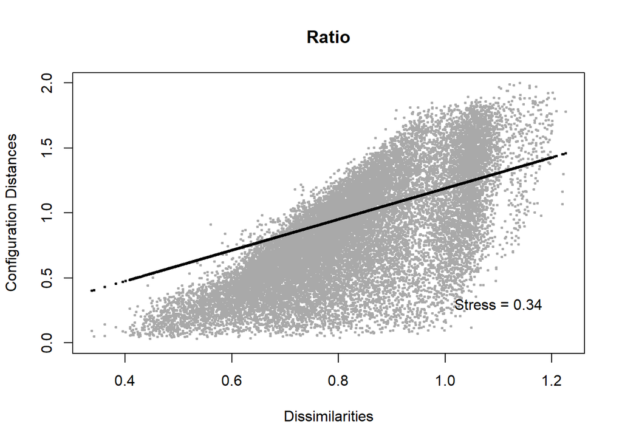

```r
MDS_ratio <- mds(dissimilarities, type = "ratio")
plot(MDS_ratio, plot.type = "Shepard", main = "Ratio")
text(1.1,0.3, paste("Stress =", round(MDS_ratio$stress,2)))
```

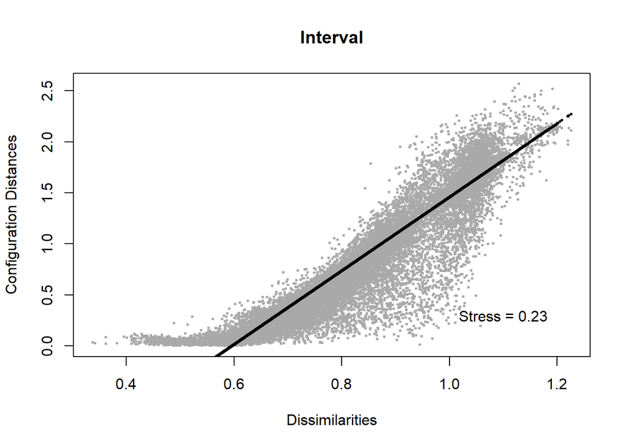

```r
MDS_interval <- mds(dissimilarities, type = "interval")
plot(MDS_interval, plot.type = "Shepard", main = "Interval")
text(1.1,0.3, paste("Stress =", round(MDS_interval$stress,2)))
```

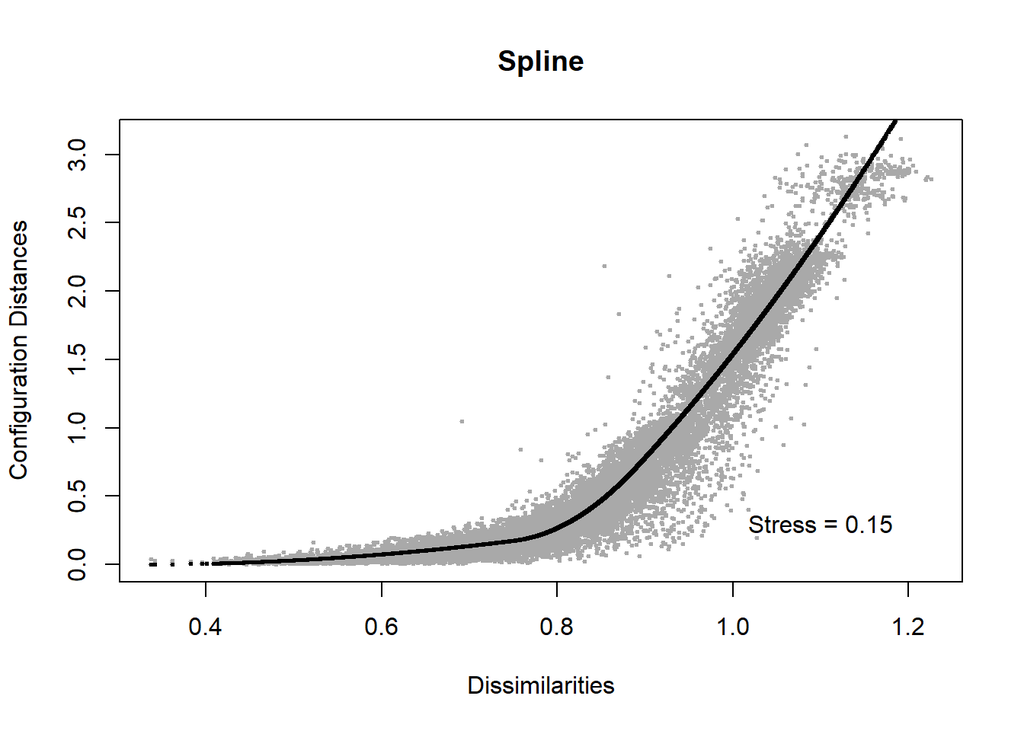

```r
MDS_mspline <- mds(dissimilarities, type = "mspline")
plot(MDS_mspline, plot.type = "Shepard", main = "Spline")
text(1.1,0.3, paste("Stress =", round(MDS_mspline$stress,2)))
```

#### All the scales with MDS Ordinal transformation

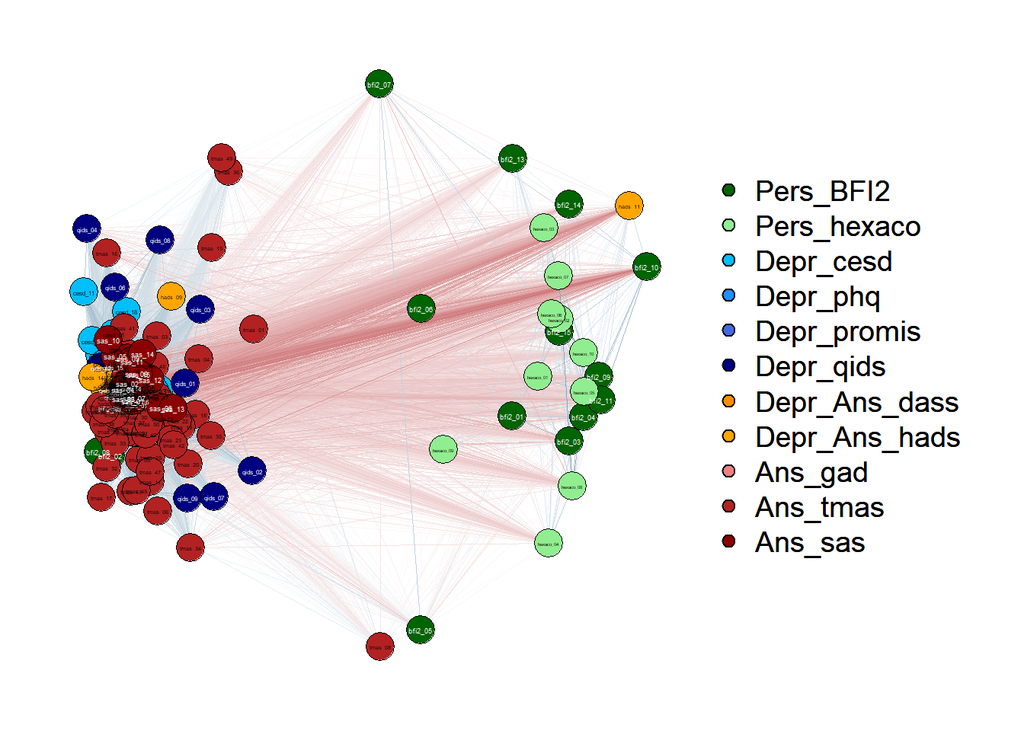

```r
groups <- list(Pers_BFI2 = 1:15, Pers_hexaco = 16:25, Depr_cesd = 26:45, Depr_phq = 46:55, Depr_promis = 56:83, Depr_qids = 84:100, Depr_Ans_dass = 101:120, Depr_Ans_hads = 121:134, Ans_gad = 135:141, Ans_tmas = 142:191, Ans_sas = 192:206)


color_nodes <- c("darkgreen", "lightgreen", "deepskyblue", "dodgerblue", "royalblue", "navy", "darkorange", "orange", "lightcoral", "firebrick", "darkred")


gen_zeroorder <- cor(df[9:214])

qgraph(gen_zeroorder, layout=MDS_ordinal$conf, labels = colnames(gen_zeroorder), groups = groups , color = color_nodes, theme="TeamFortress", height = 180, width = 140, vsize=3)
```

#### Depression and anxiety scales with MDS Ordinal transformation

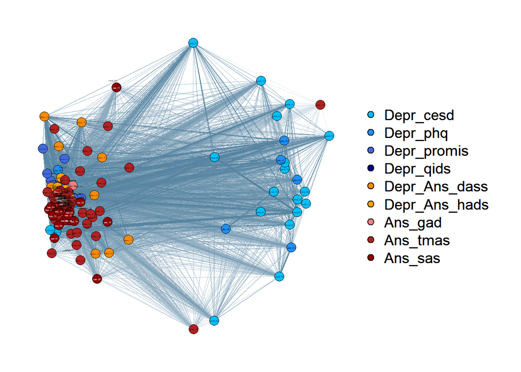

```r
dep_anx_mds_qg <- qgraph(symp_zeroorder, layout= MDS_ordinal$conf, labels = colnames(symp_zeroorder), groups = groups_anx_dep , color = color_nodes_anx_dep, theme="TeamFortress", vsize=2)
```

# From this point consider all a draft

### Centrality Measures on MDS (to continue…)

Let’s explore the centrality. We order the items with the highest outdegrees and, then, highest Betweenness. Outdegree in a correlation matrix network could be defined as the sum of variable correlations that have edges with a specific node. Due to the nature of the undirected edges based on correlation matrices, outdegrees and indegrees are redundant measures. In the code below we will identify the 50 most influential nodes and build a matrix network with them.

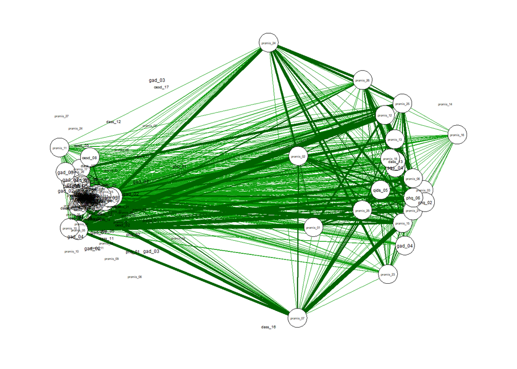

```r
centrality_dep_anx_mds_qg <- centrality(dep_anx_mds_qg)

centrality_dep_anx_mds_qg <- as.data.frame(centrality_dep_anx_mds_qg) %>%
arrange(desc(OutDegree), desc(Betweenness))

cent_dep_anx_mds_qg_50_degrees <- as.vector(rownames(centrality_dep_anx_mds_qg))[1:50]

sub_top50_degree_df <- df[cent_dep_anx_mds_qg_50_degrees]

sub_top50_degree_df_cor <- cor(sub_top50_degree_df)

diss_sub_top50_degree_df <- sim2diss(sub_top50_degree_df_cor)

MDS_ord_sub_top50_degree <- mds(dissimilarities, type = 'ordinal')


qgraph(sub_top50_degree_df_cor, layout= MDS_ord_sub_top50_degree$conf, labels = colnames(sub_top50_degree_df_cor),  vsize=4)
```

```r
z_central <- (centrality_dep_anx_mds_qg$OutDegree - mean(centrality_dep_anx_mds_qg$OutDegree)) / sd(centrality_dep_anx_mds_qg$OutDegree)
z_bet <- (centrality_dep_anx_mds_qg$Betweenness - mean(centrality_dep_anx_mds_qg$Betweenness)) / sd(centrality_dep_anx_mds_qg$Betweenness)
```

```r
mm_central <- ((centrality_dep_anx_mds_qg$OutDegree - min(centrality_dep_anx_mds_qg$OutDegree)) / (max(centrality_dep_anx_mds_qg$OutDegree) - min(centrality_dep_anx_mds_qg$OutDegree))) * 3

mm_bet <- ((centrality_dep_anx_mds_qg$Betweenness - min(centrality_dep_anx_mds_qg$Betweenness)) / (max(centrality_dep_anx_mds_qg$Betweenness) - min(centrality_dep_anx_mds_qg$Betweenness))) * 3
```

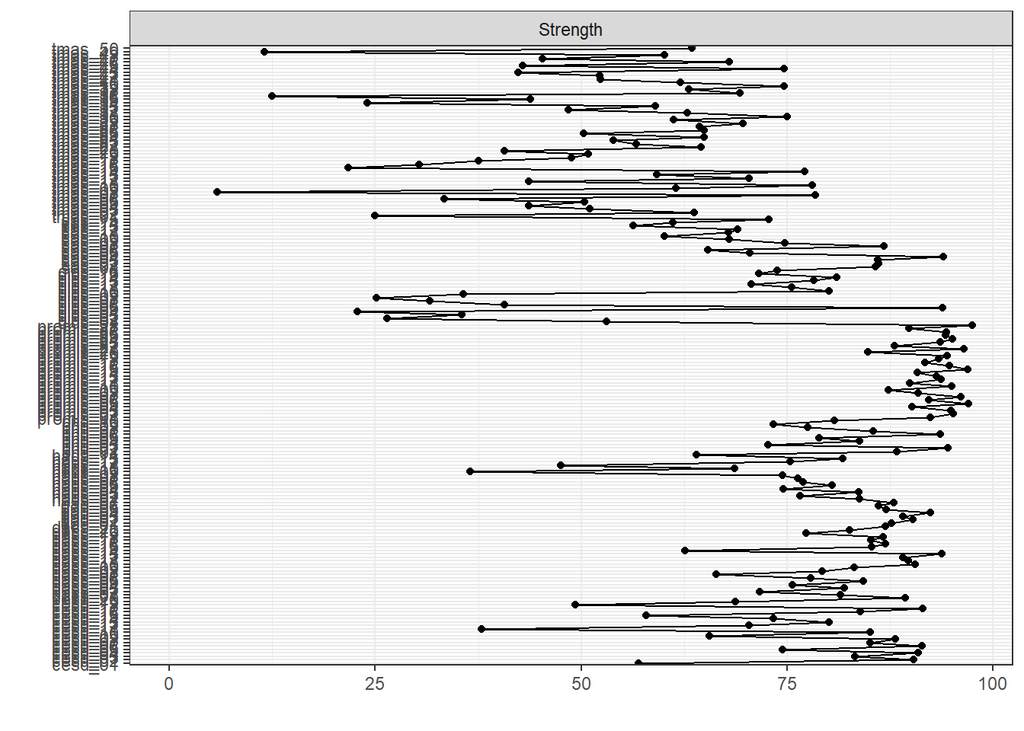

```r
plot_output <- centralityPlot(dep_anx_mds_qg)
```

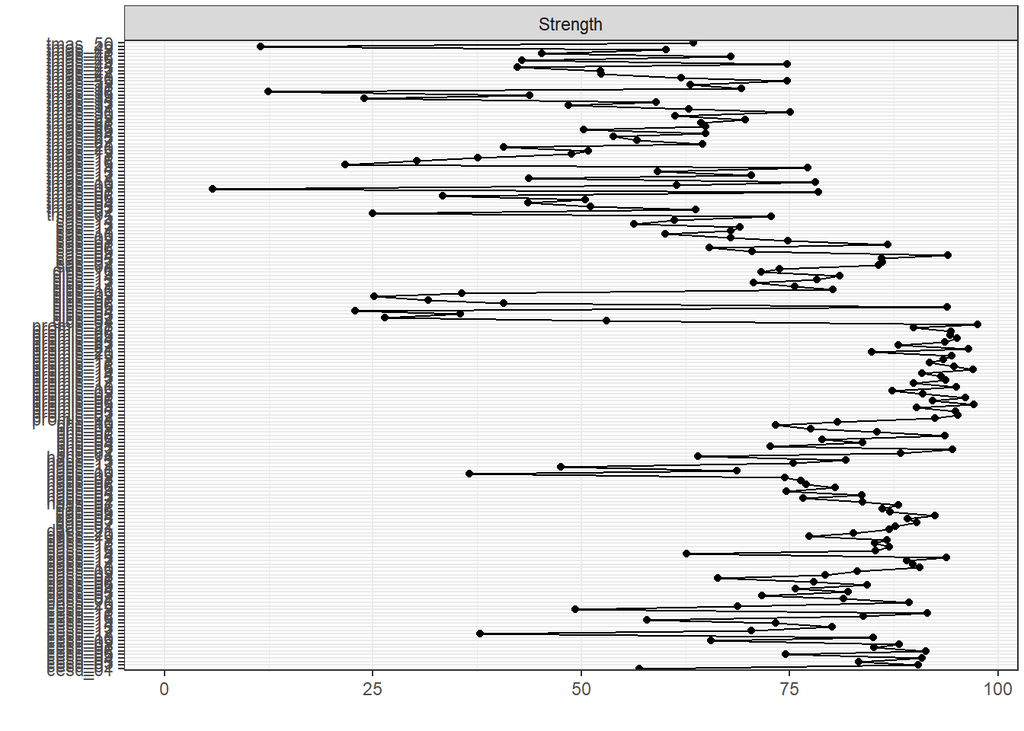

```r
plot_output + theme(plot.margin = margin(t = 0.1, r = 0.10, b = 0.10, l = 0.10, unit = "cm"), label.cex = 1)
```

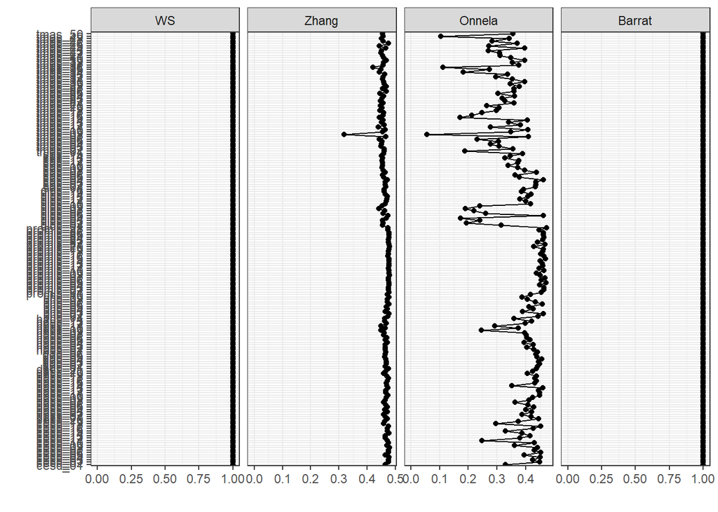

```r
ggsave("my_plot.png", plot_output, width = 10, height = 20, units = "in", limitsize = FALSE)

clusteringPlot(dep_anx_mds_qg)
```

```r
centrality_dep_anx_mds_qg <- centrality(dep_anx_mds_qg)

centrality_dep_anx_mds_qg <- as.data.frame(centrality_dep_anx_mds_qg) %>%
arrange(desc(OutDegree), desc(Betweenness))

centrality_dep_anx_mds_qg[1:5]
```

```
##           OutDegree  InDegree    Closeness Betweenness InExpectedInfluence
## promis_28 97.521706 97.521706 0.0025382484          68          96.7910116
## promis_05 97.086627 97.086627 0.0024983826          12          96.4120165
## promis_15 96.987699 96.987699 0.0024872437          14          96.3306245
## promis_21 96.499812 96.499812 0.0024746334          48          95.8893308
## promis_07 96.126323 96.126323 0.0024882155          20          95.4314326
## promis_02 95.201482 95.201482 0.0024686211          10          94.5449550
## promis_24 95.121733 95.121733 0.0024476688           4          94.4262591
## promis_10 94.976680 94.976680 0.0024499567          40          94.3563269
## promis_03 94.921316 94.921316 0.0024588470           8          94.3882659
## promis_16 94.749457 94.749457 0.0024771161          34          94.0875063
## phq_02    94.517006 94.517006 0.0024330352          10          93.9486281
## promis_19 94.484168 94.484168 0.0024449933          10          93.7223878
## promis_26 94.319599 94.319599 0.0024267366          36          93.7579435
## promis_25 94.293353 94.293353 0.0024414299          14          93.6833826
## sas_04    94.012825 94.012825 0.0024725533         194          93.3774313
## qids_05   93.910523 93.910523 0.0024555654          26          93.2264214
## dass_13   93.847868 93.847868 0.0024604598          52          93.1673046
## promis_12 93.700217 93.700217 0.0024194554           2          93.0875925
## promis_23 93.649985 93.649985 0.0024282603         126          92.9776342
## phq_06    93.590002 93.590002 0.0024200503          26          93.0401103
## promis_18 93.461095 93.461095 0.0024320705           2          92.8723369
## promis_13 93.161767 93.161767 0.0024091123           2          92.5888528
## gad_04    92.451601 92.451601 0.0024537163         154          91.5784515
## promis_01 92.410681 92.410681 0.0023918821          10          91.8711654
## promis_06 92.204138 92.204138 0.0024049188           2          91.6526783
## promis_17 91.778818 91.778818 0.0023922046          70          91.0859752
## cesd_17   91.495664 91.495664 0.0023885037         286          90.9904772
## cesd_06   91.376018 91.376018 0.0023696409          16          90.8124974
## promis_08 90.977175 90.977175 0.0023429716          18          90.4504496
## cesd_04   90.927732 90.927732 0.0023407104           8          90.3489916
## promis_14 90.863291 90.863291 0.0023475896           6          90.2789266
## dass_10   90.568055 90.568055 0.0023583540           0          89.8754093
## cesd_02   90.403702 90.403702 0.0023460626          28          89.8355768
## gad_02    90.259186 90.259186 0.0023897590           2          89.4679407
## promis_04 90.218691 90.218691 0.0023466735           0          89.5460165
## promis_11 89.900519 89.900519 0.0023449373           0          89.2930433
## promis_27 89.857393 89.857393 0.0023597612          34          89.3148403
## dass_11   89.759477 89.759477 0.0023864692          22          88.9284040
## cesd_20   89.370232 89.370232 0.0023551513          40          88.7988560
```

[output cut: 127 more lines]

```
## hads_09   36.549168 36.549168 0.0011381623           0          36.1517216
## qids_09   35.688482 35.688482 0.0011082300           2          34.7377951
## qids_03   35.510326 35.510326 0.0011009319           0          35.1135175
## tmas_06   33.411985 33.411985 0.0010391968           0          33.0500448
## qids_07   31.658608 31.658608 0.0011024238           0          30.8175500
## tmas_16   30.317730 30.317730 0.0010253767           0          29.8209873
## qids_02   26.456532 26.456532 0.0009992551           0          26.0790594
## qids_08   25.179234 25.179234 0.0009033892           0          24.3534578
## tmas_01   24.973519 24.973519 0.0008619179           0          24.7238517
## tmas_34   23.997646 23.997646 0.0008895798           0          23.4390132
## qids_04   22.824288 22.824288 0.0008790048           0          22.5905516
## tmas_15   21.715690 21.715690 0.0007685663           0          21.5247908
## tmas_36   12.456185 12.456185 0.0006633714           4          12.0950393
## tmas_49   11.551210 11.551210 0.0006107638           0          10.8625460
## tmas_08    5.760079  5.760079 0.0005367077           0          -0.9347522
```

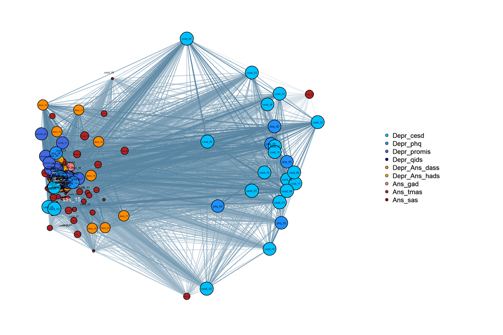

```r
qgraph(symp_zeroorder, layout= MDS_ordinal$conf, labels = colnames(symp_zeroorder), groups = groups_anx_dep , color = color_nodes_anx_dep, theme="TeamFortress", vsize=mm_central)
```